# STAT 380 Final Project

Ishan Agrahar, Noah Tobias, Matt Collins

2025-12-04

## Front Matter

```r
rm(list=ls())

# Libraries
library(dplyr)
library(tidyverse)
library(kableExtra)
library(randomForest)
library(pROC)
library(e1071)
# Dataset Read-in
CODModes <- read.csv("Raw Data/CODGameModes.csv")
CODGamesP1 <- read.csv("Raw Data/CODGames_p1_380.csv")
CODGamesP2 <- read.csv("Raw Data/CODGames_p2_380.csv")
CODMaps <- read.csv("Raw Data/CODMaps.csv")

# # Noah's base path (Windows)
# noah_path <- "C:/Users/Noah/Downloads"
#
# # Dataset Read-in (files are directly in Downloads)
# CODModes   <- read.csv(file.path(noah_path, "CODGameModes.csv"))
# CODGamesP1 <- read.csv(file.path(noah_path, "CODGames_p1_380.csv"))
# CODGamesP2 <- read.csv(file.path(noah_path, "CODGames_p2_380.csv"))
# CODMaps    <- read.csv(file.path(noah_path, "CODMaps.csv"))
```

## Quick Dataset Checking

### Modes Dataset

```r
str(CODModes)
```

```
## 'data.frame':    4 obs. of  3 variables:
##  $ Mode      : chr  "Domination" "Kill Confirmed" "Hardpoint" "TDM"
##  $ ScoreLimit: int  200 65 250 100
##  $ TimeLimit : chr  "None" "10 Minutes" "5 Minutes" "10 Minutes"
```

### Player 1 Games Dataset

```r
str(CODGamesP1)
```

```
## 'data.frame':    589 obs. of  27 variables:
##  $ Map1          : chr  "Moscow" "Moscow" "" "Drive-In" ...
##  $ Map2          : chr  "Miami Strike" "WMD" "" "Jungle" ...
##  $ Choice        : chr  "Miami Strike" "Moscow" "Yamantau" "Drive-In" ...
##  $ MapVote       : chr  "5 to 0" "2 to 0" "" "2 to 0" ...
##  $ Date          : chr  "6/6/22" "6/6/22" "6/6/22" "6/6/22" ...
##  $ FullPartial   : chr  "Full" "Full" "Full" "Full" ...
##  $ Result        : chr  "100-97" "76-89" "100-92" "80-100" ...
##  $ Eliminations  : int  22 20 18 10 11 7 10 18 4 11 ...
##  $ Deaths        : int  17 15 11 19 19 18 21 14 4 23 ...
##  $ Score         : int  4070 5305 3335 2170 2195 850 2240 3505 965 1985 ...
##  $ Damage        : int  634 560 483 280 308 196 259 504 111 304 ...
##  $ TotalXP       : int  11002 9451 12948 11502 11133 10077 8527 16703 7778 10404 ...
##  $ PrimaryWeapon : chr  "M16" "M16" "M16" "M16" ...
##  $ XPType        : chr  "10% Boost" "10% Boost" "10% Boost" "Double XP + 10%" ...
##  $ DidPlayerVote : chr  "No" "No" "No" "No" ...
##  $ GameType      : chr  "HC - TDM" "HC - TDM" "HC - TDM" "HC - TDM" ...
##  $ Confirms      : int  NA NA NA NA NA NA NA NA 5 8 ...
##  $ Denies        : int  NA NA NA NA NA NA NA NA 1 4 ...
##  $ Objectives    : int  NA NA NA NA NA NA NA NA 6 12 ...
##  $ ObjectiveKills: int  NA NA NA NA NA NA NA NA NA NA ...
##  $ Captures      : int  NA NA NA NA NA NA NA NA NA NA ...
##  $ Diffuses      : logi  NA NA NA NA NA NA ...
##  $ Plants        : logi  NA NA NA NA NA NA ...
##  $ Detonates     : logi  NA NA NA NA NA NA ...
##  $ Deposits      : logi  NA NA NA NA NA NA ...
##  $ Time_Sec      : int  NA NA NA NA NA NA NA NA NA NA ...
##  $ Time_Min      : int  NA NA NA NA NA NA NA NA NA NA ...
```

### Player 2 Games Dataset

```r
str(CODGamesP2)
```

```
## 'data.frame':    250 obs. of  27 variables:
##  $ Map1          : chr  "Yamantau" "Deprogram" "Yamantau" "" ...
##  $ Map2          : chr  "Collateral Strike" "Cartel" "Miami Strike" "" ...
##  $ Choice        : chr  "Collateral Strike" "Deprogram" "Yamantau" "Amerika" ...
##  $ MapVote       : chr  "2 to 1" "2 to 2" "0 to 0" "" ...
##  $ Date          : chr  "12/11/21" "12/11/21" "12/11/21" "12/11/21" ...
##  $ FullPartial   : chr  "Full" "Full" "Full" "Full" ...
##  $ Result        : chr  "189-250" "202-250" "250-11" "250-202" ...
##  $ Eliminations  : int  22 20 7 15 22 24 28 NA 13 13 ...
##  $ Deaths        : int  25 25 5 24 30 16 14 NA 6 16 ...
##  $ Score         : int  3705 2560 1875 2405 2520 3810 2940 NA 960 2205 ...
##  $ Damage        : int  576 524 182 383 567 673 719 NA 334 364 ...
##  $ TotalXP       : int  11699 16068 13194 19936 19138 25559 22369 NA 11270 25263 ...
##  $ PrimaryWeapon : chr  "MG 82" "MG 82" "MG 82" "MG 82" ...
##  $ XPType        : chr  "10% Boost" "Double XP + 10%" "Double XP + 10%" "Double XP + 10%" ...
##  $ DidPlayerVote : chr  "No" "No" "No" "No" ...
##  $ GameType      : chr  "HC - Hardpoint" "HC - Hardpoint" "HC - Hardpoint" "HC - Hardpoint" ...
##  $ Confirms      : int  NA NA NA NA NA NA NA NA NA NA ...
##  $ Denies        : int  NA NA NA NA NA NA NA NA NA NA ...
##  $ Objectives    : int  NA NA NA NA NA NA NA NA NA NA ...
##  $ ObjectiveKills: int  9 8 4 1 14 6 10 NA 1 NA ...
##  $ Captures      : int  NA NA NA NA NA NA NA NA NA NA ...
##  $ Diffuses      : logi  NA NA NA NA NA NA ...
##  $ Plants        : logi  NA NA NA NA NA NA ...
##  $ Detonates     : logi  NA NA NA NA NA NA ...
##  $ Deposits      : logi  NA NA NA NA NA NA ...
##  $ Time_Sec      : int  57 35 8 40 4 4 9 NA 9 NA ...
##  $ Time_Min      : int  1 1 2 1 1 1 2 NA 0 NA ...
```

### Maps Dataset

```r
str(CODMaps)
```

```
## 'data.frame':    28 obs. of  3 variables:
##  $ Name          : chr  "Armada Strike" "Cartel" "Checkmate" "Crossroads Strike" ...
##  $ FirstAvailable: chr  "Launch" "Launch" "Launch" "Launch" ...
##  $ Date          : chr  "11/13/20" "11/13/20" "11/13/20" "11/13/20" ...
```

Looking through the data overviews, I do not see any concerns.

## Combining Player Data

Looking at both the Player 1 and Player 2 datasets, it seems that they have the same column names so I will just add a row denoting player 1 or player 2 and perform a row bind.

```r
CODGamesAllPlayers <-
  rbind(CODGamesP1 %>% mutate(playerNum = 1),
        CODGamesP2 %>% mutate(playerNum = 2))
```

### Checking Dataset

```r
str(CODGamesAllPlayers)
```

```
## 'data.frame':    839 obs. of  28 variables:
##  $ Map1          : chr  "Moscow" "Moscow" "" "Drive-In" ...
##  $ Map2          : chr  "Miami Strike" "WMD" "" "Jungle" ...
##  $ Choice        : chr  "Miami Strike" "Moscow" "Yamantau" "Drive-In" ...
##  $ MapVote       : chr  "5 to 0" "2 to 0" "" "2 to 0" ...
##  $ Date          : chr  "6/6/22" "6/6/22" "6/6/22" "6/6/22" ...
##  $ FullPartial   : chr  "Full" "Full" "Full" "Full" ...
##  $ Result        : chr  "100-97" "76-89" "100-92" "80-100" ...
##  $ Eliminations  : int  22 20 18 10 11 7 10 18 4 11 ...
##  $ Deaths        : int  17 15 11 19 19 18 21 14 4 23 ...
##  $ Score         : int  4070 5305 3335 2170 2195 850 2240 3505 965 1985 ...
##  $ Damage        : int  634 560 483 280 308 196 259 504 111 304 ...
##  $ TotalXP       : int  11002 9451 12948 11502 11133 10077 8527 16703 7778 10404 ...
##  $ PrimaryWeapon : chr  "M16" "M16" "M16" "M16" ...
##  $ XPType        : chr  "10% Boost" "10% Boost" "10% Boost" "Double XP + 10%" ...
##  $ DidPlayerVote : chr  "No" "No" "No" "No" ...
##  $ GameType      : chr  "HC - TDM" "HC - TDM" "HC - TDM" "HC - TDM" ...
##  $ Confirms      : int  NA NA NA NA NA NA NA NA 5 8 ...
##  $ Denies        : int  NA NA NA NA NA NA NA NA 1 4 ...
##  $ Objectives    : int  NA NA NA NA NA NA NA NA 6 12 ...
##  $ ObjectiveKills: int  NA NA NA NA NA NA NA NA NA NA ...
##  $ Captures      : int  NA NA NA NA NA NA NA NA NA NA ...
##  $ Diffuses      : logi  NA NA NA NA NA NA ...
##  $ Plants        : logi  NA NA NA NA NA NA ...
##  $ Detonates     : logi  NA NA NA NA NA NA ...
##  $ Deposits      : logi  NA NA NA NA NA NA ...
##  $ Time_Sec      : int  NA NA NA NA NA NA NA NA NA NA ...
##  $ Time_Min      : int  NA NA NA NA NA NA NA NA NA NA ...
##  $ playerNum     : num  1 1 1 1 1 1 1 1 1 1 ...
```

Looking at the dataset overview, I see no concerns as 839 observations = 589 obs. (from player 1) + 250 obs.(from player 2).

## Task #1

The research question for this task is: Which maps are the most likely to win the map vote when they are an option?

According to the relevant information part of the instruction guide, players are given two choices represented in the `Map1` and `Map2` variables. There also is a `MapVote` variable which shows the voting tally and can also serve as a filter of that which there are no player votes. The winning map vote is then placed in the `Choice` variable. Also according to the problem guidance, there is data quality issues. Focusing on the variables above, the first step I must take is to fix the data quality issues. To address this I will first look at if there are missing values in any of these columns and likely remove them. Then I shall at each of the unique data observations to see if there is spelling issues. I will validate this by looking at the differences between the CODMaps Names that are apparently all correct. Note: I do recognize that we: “should consider whether a given map won the vote by getting more votes than the other option or if it was selected since it was `Map1` and the vote was a tie.” It is evident from the research question that we need to consider maps that win the map vote. If a map did not win as a result of a map vote, that is not considered a win by our research question and therefore all blank entries as well as ties must be denoted as losses. That can be done by making an indicator variable of tie or not tie. That should alleviate data quality concerns hopefully. The second step would then be to use the hint given in the document to make a: “table in your report showing the name of the map, the number of times it was a candidate, the number of times it won the vote, and the proportion/probability.” The number of times a map appears as a candidate and number of times it won are simply a matter of making the data into a 0 or 1, or True or False thing of is it a map name and then simply summing across respective column. As such, the answer to the research question should be based on that proportion/probability of how many times a map won its vote. The most likely is a subjective number where I will simply present a table of the proportions from largest to smallest where the viewer can be like I consider this many to be the most likely number of maps.

### Data Cleaning

First I will check if there is NA’s

```r
sum(is.na(CODGamesAllPlayers$Map1))
```

```
## [1] 0
```

```r
sum(is.na(CODGamesAllPlayers$Map2))
```

```
## [1] 0
```

```r
sum(is.na(CODGamesAllPlayers$MapVote))
```

```
## [1] 0
```

```r
sum(is.na(CODGamesAllPlayers$Choice))
```

```
## [1] 0
```

There are no NA’s in the data

Next I will check the differences between the map names in these categories with the correct ones from the COD MAPS dataset.

```r
setdiff(CODGamesAllPlayers$Map1, CODMaps$Name)
```

```
##  [1] ""                  "Jungle "           "Ruah"
##  [4] "Collateral"        "Riad"              "Miami "
##  [7] "Collateral Striek" "Miami Stirke"      "Collaterol Strike"
## [10] "Drive-in"          "Deprogam"          "Rush "
## [13] "Zoo "              "Raid "
```

```r
setdiff(CODGamesAllPlayers$Map2, CODMaps$Name)
```

```
## [1] ""                       "Miami Stirke"           "Collateral"
## [4] "yamantau"               "Drive-in"               "Nuketown '84 Halloween"
## [7] "Miami Sstrike"          "Amrada Strike"
```

```r
setdiff(CODGamesAllPlayers$Choice, CODMaps$Name)
```

```
## [1] ""                       "Apocolypse"             "Collateral"
## [4] "APocalypse"             "Drive-in"               "Collaterel Strike"
## [7] "Nuketown '84 Halloween" "Deisel"                 "Riad"
```

Looking like there are “” instead of NAs. I will manually correct the all of those wrong names.

Correct Map Names are as follows

```r
data.frame(Names = CODMaps$Name) %>%
  arrange(Names) %>%
  kable()
```

| Names |
| --- |
| Amerika |
| Apocalypse |
| Armada Strike |
| Cartel |
| Checkmate |
| Collateral Strike |
| Crossroads Strike |
| Deprogram |
| Diesel |
| Drive-In |
| Echelon |
| Express |
| Garrison |
| Hijacked |
| Jungle |
| Miami |
| Miami Strike |
| Moscow |
| Nuketown ’84 |
| Raid |
| Rush |
| Satellite |
| Slums |
| Standoff |
| The Pines |
| WMD |
| Yamantau |
| Zoo |

#### Manual Correction

NOTE I WILL CLEAN AND NAME THE DATASET `CODGamesAllPlayersCleaned`!

##### Map1 Variable

Differences are:

```r
setdiff(CODGamesAllPlayers$Map1, CODMaps$Name)
```

```
##  [1] ""                  "Jungle "           "Ruah"
##  [4] "Collateral"        "Riad"              "Miami "
##  [7] "Collateral Striek" "Miami Stirke"      "Collaterol Strike"
## [10] "Drive-in"          "Deprogam"          "Rush "
## [13] "Zoo "              "Raid "
```

Using my best guess of what they are:

```r
CODGamesAllPlayersCleaned <- CODGamesAllPlayers %>%
  filter(Map1 != "")

CODGamesAllPlayersCleaned$Map1[CODGamesAllPlayersCleaned$Map1 == "Jungle "] <- "Jungle"
CODGamesAllPlayersCleaned$Map1[CODGamesAllPlayersCleaned$Map1 == "Ruah"] <- "Rush"
CODGamesAllPlayersCleaned$Map1[CODGamesAllPlayersCleaned$Map1 == "Collateral"] <- "Collateral Strike"
CODGamesAllPlayersCleaned$Map1[CODGamesAllPlayersCleaned$Map1 == "Riad"] <- "Raid"
CODGamesAllPlayersCleaned$Map1[CODGamesAllPlayersCleaned$Map1 == "Miami "] <- "Miami"
CODGamesAllPlayersCleaned$Map1[CODGamesAllPlayersCleaned$Map1 == "Collateral Striek"] <- "Collateral Strike"
CODGamesAllPlayersCleaned$Map1[CODGamesAllPlayersCleaned$Map1 == "Miami Stirke"] <- "Miami Strike"
CODGamesAllPlayersCleaned$Map1[CODGamesAllPlayersCleaned$Map1 == "Collaterol Strike"] <- "Collateral Strike"
CODGamesAllPlayersCleaned$Map1[CODGamesAllPlayersCleaned$Map1 == "Drive-in"] <- "Drive-In"
CODGamesAllPlayersCleaned$Map1[CODGamesAllPlayersCleaned$Map1 == "Deprogam"] <- "Deprogram"
CODGamesAllPlayersCleaned$Map1[CODGamesAllPlayersCleaned$Map1 == "Rush "] <- "Rush"
CODGamesAllPlayersCleaned$Map1[CODGamesAllPlayersCleaned$Map1 == "Zoo "] <- "Zoo"
CODGamesAllPlayersCleaned$Map1[CODGamesAllPlayersCleaned$Map1 == "Raid "] <- "Raid"
```

Checking if I got all of them

```r
setdiff(CODGamesAllPlayersCleaned$Map1, CODMaps$Name)
```

```
## character(0)
```

Yay!

##### Map2 Variable

Differences are:

```r
setdiff(CODGamesAllPlayersCleaned$Map2, CODMaps$Name)
```

```
## [1] "Miami Stirke"           "Collateral"             "yamantau"
## [4] "Drive-in"               "Nuketown '84 Halloween" "Miami Sstrike"
## [7] "Amrada Strike"
```

Using my best guess of what they are:

```r
CODGamesAllPlayersCleaned$Map2[CODGamesAllPlayersCleaned$Map2 == "Miami Stirke"] <- "Miami Strike"
CODGamesAllPlayersCleaned$Map2[CODGamesAllPlayersCleaned$Map2 == "Collateral"] <- "Collateral Strike"
CODGamesAllPlayersCleaned$Map2[CODGamesAllPlayersCleaned$Map2 == "yamantau"] <- "Yamantau"
CODGamesAllPlayersCleaned$Map2[CODGamesAllPlayersCleaned$Map2 == "Drive-in"] <- "Drive-In"
CODGamesAllPlayersCleaned$Map2[CODGamesAllPlayersCleaned$Map2 == "Nuketown '84 Halloween"] <- "Nuketown '84"
CODGamesAllPlayersCleaned$Map2[CODGamesAllPlayersCleaned$Map2 == "Miami Sstrike"] <- "Miami Strike"
CODGamesAllPlayersCleaned$Map2[CODGamesAllPlayersCleaned$Map2 == "Amrada Strike"] <- "Armada Strike"
```

Checking if I got all of them

```r
setdiff(CODGamesAllPlayersCleaned$Map2, CODMaps$Name)
```

```
## character(0)
```

Yay!

##### Choice Variable

Differences are:

```r
setdiff(CODGamesAllPlayersCleaned$Choice, CODMaps$Name)
```

```
## [1] "Apocolypse"             "Collateral"             "APocalypse"
## [4] "Drive-in"               "Collaterel Strike"      "Nuketown '84 Halloween"
## [7] "Deisel"
```

Using my best guess of what they are:

```r
CODGamesAllPlayersCleaned$Choice[CODGamesAllPlayersCleaned$Choice == "Apocolypse"] <- "Apocalypse"
CODGamesAllPlayersCleaned$Choice[CODGamesAllPlayersCleaned$Choice == "Collateral"] <- "Collateral Strike"
CODGamesAllPlayersCleaned$Choice[CODGamesAllPlayersCleaned$Choice == "APocalypse"] <- "Apocalypse"
CODGamesAllPlayersCleaned$Choice[CODGamesAllPlayersCleaned$Choice == "Drive-in"] <- "Drive-In"
CODGamesAllPlayersCleaned$Choice[CODGamesAllPlayersCleaned$Choice == "Collaterel Strike"] <- "Collateral Strike"
CODGamesAllPlayersCleaned$Choice[CODGamesAllPlayersCleaned$Choice == "Nuketown '84 Halloween"] <- "Nuketown '84"
CODGamesAllPlayersCleaned$Choice[CODGamesAllPlayersCleaned$Choice == "Deisel"] <- "Diesel"
```

Checking if I got all of them

```r
setdiff(CODGamesAllPlayersCleaned$Choice, CODMaps$Name)
```

```
## character(0)
```

Yay!

#### Remove Ties & No Votes

First checking the unique values if there are any NAs or ““.

```r
unique(CODGamesAllPlayersCleaned$MapVote)
```

```
##  [1] "5 to 0"  "2 to 0"  "3 to 3"  "4 to 3"  "5 to 1"  "1 to 0"  "1 to 1"
##  [8] "3 to 1"  "4 to 2"  "0 to 0"  "2 to 2"  "2 to 1"  "7 to 1"  "4 to 0"
## [15] "3 to 2"  "6 to 1"  "3 to 0"  "6 to 0"  "5 to 2"  "4 to 1"  "4 to 4"
## [22] "7 to 0"  "3 to 2 " "2 to 0 " "6 to 2"  "5 to 3"  "5 to 4"  "4 o 0"
## [29] "2 o 0"
```

There does not seem to be any missing votes here so I can proceed to removing Ties, however, I do see that in some of them there is an inconsistent delimiter. I can see a pattern though that there is only single digit votes and therefore the numbers I need are the first character and the last character.

I realistically do not care who wins the vote and only care if the first and last numbers are the same. So there is no need to store the numbers and I will just do a comparison in an ifelse and set the indicator based on that (`tieIndicator` = 1 if tie, 0 otherwise). I have no clue how to get the first and last characters of a string in R because in python it would be intuitive as a string is an iterable and I could index at 0 and -1 but for whatever reason R is not the same :(. I therefore searched how do I get the first and last letter of a string in r on google and got the str_sub function from tidyverse as the solution.

```r
CODGamesAllPlayersCleaned <-
  CODGamesAllPlayersCleaned %>%
  mutate(
    tieIndicator = ifelse(
      str_sub(CODGamesAllPlayersCleaned$MapVote, 1, 1) != str_sub(CODGamesAllPlayersCleaned$MapVote, -1, -1),
      0,
      1)
    )
```

Checking if it worked

```r
CODGamesAllPlayersCleaned %>%
  select(MapVote, tieIndicator) %>%
  head(10) %>%
  kable()
```

| MapVote | tieIndicator |
| --- | --- |
| 5 to 0 | 0 |
| 2 to 0 | 0 |
| 2 to 0 | 0 |
| 3 to 3 | 1 |
| 4 to 3 | 0 |
| 5 to 1 | 0 |
| 1 to 0 | 0 |
| 1 to 1 | 1 |
| 1 to 0 | 0 |
| 1 to 1 | 1 |

It worked, yay!

That should hopefully conclude the data cleaning part.

### Table of Map Candidacy and Chosen Rate

First I need to identify the number of times a map is a candidate. This can probably be done through a summarize on `Map1` and `Map2` then joining those tables and once again summarize.

```r
CandicacyMap <- full_join(
  CODGamesAllPlayersCleaned %>% group_by(Map1) %>% summarize(n = n()),
  CODGamesAllPlayersCleaned %>% group_by(Map2) %>% summarize(n = n()),
  by = join_by(Map1 == Map2))

CandicacyMap %>% kable()
```

| Map1 | n.x | n.y |
| --- | --- | --- |
| Amerika | 11 | 16 |
| Apocalypse | 36 | 27 |
| Armada Strike | 23 | 22 |
| Cartel | 30 | 37 |
| Checkmate | 34 | 21 |
| Collateral Strike | 26 | 32 |
| Crossroads Strike | 24 | 34 |
| Deprogram | 14 | 27 |
| Diesel | 29 | 26 |
| Drive-In | 24 | 19 |
| Echelon | 25 | 20 |
| Express | 32 | 30 |
| Garrison | 25 | 27 |
| Hijacked | 22 | 27 |
| Jungle | 10 | 4 |
| Miami | 11 | 14 |
| Miami Strike | 27 | 32 |
| Moscow | 46 | 27 |
| Nuketown ’84 | 19 | 21 |
| Raid | 19 | 25 |
| Rush | 20 | 26 |
| Satellite | 17 | 22 |
| Slums | 22 | 19 |
| Standoff | 22 | 25 |
| The Pines | 42 | 24 |
| WMD | 7 | 8 |
| Yamantau | 31 | 38 |
| Zoo | 26 | 24 |

All 28 maps are accounted for yay! Now I just need to sum the numbers for total candidacy.

```r
CandicacyMap <-
  CandicacyMap %>%
  mutate(TotalCandidacies = n.x + n.y) %>%
  select(Map1, TotalCandidacies) %>%
  rename(MapName = Map1)

CandicacyMap %>% kable()
```

| MapName | TotalCandidacies |
| --- | --- |
| Amerika | 27 |
| Apocalypse | 63 |
| Armada Strike | 45 |
| Cartel | 67 |
| Checkmate | 55 |
| Collateral Strike | 58 |
| Crossroads Strike | 58 |
| Deprogram | 41 |
| Diesel | 55 |
| Drive-In | 43 |
| Echelon | 45 |
| Express | 62 |
| Garrison | 52 |
| Hijacked | 49 |
| Jungle | 14 |
| Miami | 25 |
| Miami Strike | 59 |
| Moscow | 73 |
| Nuketown ’84 | 40 |
| Raid | 44 |
| Rush | 46 |
| Satellite | 39 |
| Slums | 41 |
| Standoff | 47 |
| The Pines | 66 |
| WMD | 15 |
| Yamantau | 69 |
| Zoo | 50 |

Now I need to get the number of times a map won from `Choice` and is not a tie from `tieIndicator`. This is also probably through summarize but I’ll just directly join it.

```r
CandicacyMap <-
  full_join(
    CandicacyMap,
    CODGamesAllPlayersCleaned %>% filter(tieIndicator == 0) %>% group_by(Choice) %>% summarize(NumberOfSelections = n()),
    by = join_by(MapName == Choice)
  )

CandicacyMap %>% kable()
```

| MapName | TotalCandidacies | NumberOfSelections |
| --- | --- | --- |
| Amerika | 27 | 13 |
| Apocalypse | 63 | 19 |
| Armada Strike | 45 | 8 |
| Cartel | 67 | 14 |
| Checkmate | 55 | 29 |
| Collateral Strike | 58 | 30 |
| Crossroads Strike | 58 | 41 |
| Deprogram | 41 | 8 |
| Diesel | 55 | 38 |
| Drive-In | 43 | 22 |
| Echelon | 45 | 6 |
| Express | 62 | 34 |
| Garrison | 52 | 16 |
| Hijacked | 49 | 22 |
| Jungle | 14 | 3 |
| Miami | 25 | 2 |
| Miami Strike | 59 | 21 |
| Moscow | 73 | 24 |
| Nuketown ’84 | 40 | 28 |
| Raid | 44 | 32 |
| Rush | 46 | 22 |
| Satellite | 39 | 13 |
| Slums | 41 | 23 |
| Standoff | 47 | 30 |
| The Pines | 66 | 25 |
| WMD | 15 | 2 |
| Yamantau | 69 | 28 |
| Zoo | 50 | 18 |

Yay!

The last thing to do here is make the proportions (selections divided by candidacies) and then sort them. I’m also gonna change the order of selections and candidacies to make the table look more intuitive.

```r
CandicacyMap <-
  CandicacyMap %>%
  mutate(ProportionOfSelection = round(NumberOfSelections / TotalCandidacies, 4)) %>%
  arrange(desc(ProportionOfSelection)) %>%
  select(MapName, NumberOfSelections, TotalCandidacies, ProportionOfSelection)

CandicacyMap %>% kable()
```

| MapName | NumberOfSelections | TotalCandidacies | ProportionOfSelection |
| --- | --- | --- | --- |
| Raid | 32 | 44 | 0.7273 |
| Crossroads Strike | 41 | 58 | 0.7069 |
| Nuketown ’84 | 28 | 40 | 0.7000 |
| Diesel | 38 | 55 | 0.6909 |
| Standoff | 30 | 47 | 0.6383 |
| Slums | 23 | 41 | 0.5610 |
| Express | 34 | 62 | 0.5484 |
| Checkmate | 29 | 55 | 0.5273 |
| Collateral Strike | 30 | 58 | 0.5172 |
| Drive-In | 22 | 43 | 0.5116 |
| Amerika | 13 | 27 | 0.4815 |
| Rush | 22 | 46 | 0.4783 |
| Hijacked | 22 | 49 | 0.4490 |
| Yamantau | 28 | 69 | 0.4058 |
| The Pines | 25 | 66 | 0.3788 |
| Zoo | 18 | 50 | 0.3600 |
| Miami Strike | 21 | 59 | 0.3559 |
| Satellite | 13 | 39 | 0.3333 |
| Moscow | 24 | 73 | 0.3288 |
| Garrison | 16 | 52 | 0.3077 |
| Apocalypse | 19 | 63 | 0.3016 |
| Jungle | 3 | 14 | 0.2143 |
| Cartel | 14 | 67 | 0.2090 |
| Deprogram | 8 | 41 | 0.1951 |
| Armada Strike | 8 | 45 | 0.1778 |
| Echelon | 6 | 45 | 0.1333 |
| WMD | 2 | 15 | 0.1333 |
| Miami | 2 | 25 | 0.0800 |

The last step here is to make a visualization of this information on the `ProportionOfSelection`. Since we are looking at the spread of categorical data, I am just going to use a barplot.

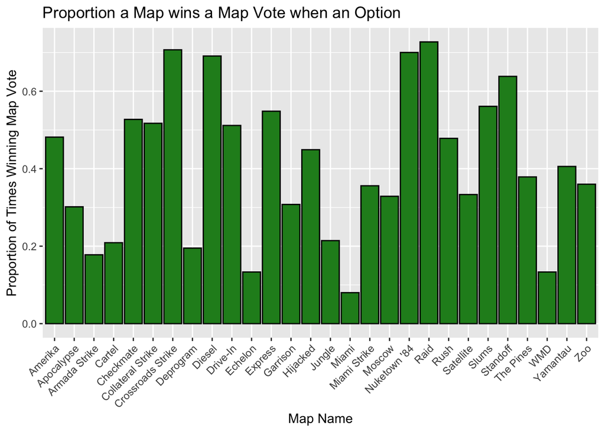

```r
# For the axis labels layer, I took that line from my (Ishan) Mini-Project 1
ggplot(CandicacyMap, aes(MapName, ProportionOfSelection)) +
  geom_col(color = "black", fill = "forestgreen") +
  theme(axis.text.x = element_text(angle = 45, vjust = 1, hjust=1)) + # Note this line was taken from: https://www.statology.org/rotate-axis-labels-ggplot2/
  xlab("Map Name") +
  ylab("Proportion of Times Winning Map Vote") +
  ggtitle("Proportion a Map wins a Map Vote when an Option")
```

### Research Question Answer

Looking mostly at the table since it is easier to look through since it is cleanly arranged, it looks like `Raid` is the most likely to be picked, followed by `Crossroads Strike`, followed by `Nuketown ’84`, continue this train of thought till you reach your desired however many is the likely number you would like.

## Task #2

For this question I used the AI model of Gemini 3.0

You may find the exact prompt and reponses from Gemini at the following link: https://gemini.google.com/share/7c470706e207

### Prompts

The first prompt that I gave R was as follows:

NOTE: I also provided Gemini with the csv files of CODGames_p1_380.csv, CODGames_p2_380.csv, and CODMaps.csv

```
Consider the following



Relevant Information: Prior to each online match, players in the game lobby are presented with two options for the battlefield of the upcoming game (`Map1` and `Map2`). The players have the option to vote, and the resulting vote is recorded in the `MapVote` column. The winning map is listed in the `Choice` column. In the event of a tie vote, the map listed in `Map1` is chosen. (Games for which the player entered the lobby after the vote has taken place have no information in `Map1` and `Map2` but have the winning map presented in `Choice`.) Research Question: Which maps are the most likely to win the map vote when they are an option? Notes: To answer this question, write a paragraph (or more) discussing how you plan to answer this question. Be sure to address the data quality issues mentioned below and discuss how you will do the calculations. Then, write code and answer the question. (If I must answer questions about your approach/decision making process by reading your code rather than your discussion, you will lose points.) As part of your solution, you should calculate the proportion/probability that a map wins the vote given that it was a candidate. To do this, you will have to calculate the number times that each map was listed as a candidate (Map1 or Map2) and earned more votes than the other candidate. As part of this, you should consider whether a given map won the vote by getting more votes than the other option or if it was selected since it was `Map1` and the vote was a tie. You should include a table in your report showing the name of the map, the number of times it was a candidate, the number of times it won the vote, and the proportion/probability. You should also include a visualization of the results. Then, write a clear answer to the research question. There might be some data quality issues (such as misspelled map names and extra (trailing) blanks in some entries) to solve for this problem. You can find the proper names/spellings in the CODMaps.csv file. To full receive full credit, you must write code to solve these issues rather than editing the .csv files.



Also find the attached csv files that are explained below:

1. CODGames_p1_380.csv contains information about the results of an online, first-person shooter video game. (Games such as Call of Duty, Fortnite, Apex Legends, Battlefield has been immensely popular in the last 5 years.) The dataset contains information about a single player, who we will call Player 1. In the game, the player is part of a team trying to win an online match against other online competitors. Points are earned for various tasks such as eliminating enemy combatants, collecting items, capturing a location, etc. Each row represents the results of a single, randomly selected, online match in which Player 1 participated. o NOTE: When reading in this dataset, make sure the variables names are Map1, Map2, Choice, etc. instead of V1, V2, … o We have seen this issue before. To solve it, click the box for Yes for Heading in the Import Dataset interface. o This is not the same dataset used in the mini-projects and may require additional cleaning.



2. CODGames_p2_380.csv is similar to CODGames_p1.csv but is for a different player, who we will call Player 2. o You will want to combine the information in this dataset with the information in CODGames_p1_380.csv into one dataset.



3. CODMaps.csv contains information about the various maps available in the game. The dataset contains 3 variables: o Name – The name of the map/battleground o FirstAvailable – The event during which the map become available (Launch, Season 1, Season 2, etc.) o Date – The date on which the map become available



Solve the Research Question: Which maps are the most likely to win the map vote when they are an option?
```

Note that the model responded in python, a language I am adept in and understand, but I realize that it is not really the intention of this class so I tried to get Gemini to turn it into R code. It does seem that Gemini converted the code to R, but it could not run it and I am hence stuck with the python run.

In attempt to do this I gave Gemini the following prompts of

```
Please provide the code in R
```

and

```
Provide the visualization as well in R
```

### Results

#### Gemini gives the following plan and approach

Plan and Approach

To answer the research question regarding which maps are most likely to win a vote, I first combined the game data from both players (CODGames_p1_380.csv and CODGames_p2_380.csv) into a single dataset. A significant challenge in this analysis was data quality; specifically, the map names contained numerous spelling errors and inconsistencies (e.g., “Ruah” for “Rush”, “Collateral Striek” for “Collateral Strike”, and trailing whitespace like “Jungle”). I addressed this by cleaning the map names in the game data, using the CODMaps.csv file as a reference for correct spellings and mapping identified typos to their canonical names.

For the calculations, I defined a map as a “candidate” if it appeared in either the Map1 or Map2 columns. To determine the win probability, I analyzed the MapVote and Choice columns. I discovered that the MapVote column consistently formats votes as “Winner’s Vote count to Loser’s Vote count” (e.g., “5 to 0” always, never “0 to 5”). Using this, I calculated two metrics:

Strict Wins: The number of times a map earned a strict majority of votes (Vote_Winner > Vote_Loser).

Total Wins: The number of times a map was the final Choice, which includes both strict majorities and instances where the map won via the tie-breaker rule (where Map1 wins if votes are equal). The final probability presented is the Total Win Rate (Total Wins / Candidacies), as this represents the true likelihood of a map being played, but the analysis effectively distinguishes between popularity (strict votes) and systemic advantage (tie-breakers).

```python
import pandas as pd
import matplotlib.pyplot as plt
import seaborn as sns

# Load datasets
df1 = pd.read_csv('CODGames_p1_380.csv')
df2 = pd.read_csv('CODGames_p2_380.csv')
cod_maps = pd.read_csv('CODMaps.csv')

# Combine game data
combined_df = pd.concat([df1, df2], ignore_index=True)

# Standardize Map Names
clean_map_names = set(cod_maps['Name'].str.strip().unique())

def clean_name(name):
    if pd.isna(name):
        return name
    name = str(name).strip()

    # Correction dictionary for identified typos
    corrections = {
        'Ruah': 'Rush', 'Riad': 'Raid', 'Raid ': 'Raid',
        'Collateral Striek': 'Collateral Strike', 'Collaterol Strike': 'Collateral Strike',
        'Collaterel Strike': 'Collateral Strike', 'Collateral': 'Collateral Strike',
        'Deisel': 'Diesel', 'Deprogam': 'Deprogram',
        'Apocolypse': 'Apocalypse', 'APocalypse': 'Apocalypse',
        'yamantau': 'Yamantau', 'Miami Stirke': 'Miami Strike',
        'Miami Sstrike': 'Miami Strike', 'Amrada Strike': 'Armada Strike',
        'Drive-in': 'Drive-In', "Nuketown '84 Halloween": "Nuketown '84",
        'Jungle ': 'Jungle', 'Rush ': 'Rush', 'Zoo ': 'Zoo', 'Miami ': 'Miami'
    }

    if name in corrections:
        return corrections[name]

    # Case insensitive match
    for valid in clean_map_names:
        if name.lower() == valid.lower():
            return valid
    return name

# Apply cleaning
combined_df['Map1'] = combined_df['Map1'].apply(clean_name)
combined_df['Map2'] = combined_df['Map2'].apply(clean_name)
combined_df['Choice'] = combined_df['Choice'].apply(clean_name)

# Filter for valid voting scenarios
vote_df = combined_df.dropna(subset=['Map1', 'Map2']).copy()

# Parse MapVote: Data inspection revealed format is "WinnerVotes to LoserVotes"
def parse_votes(vote_str):
    try:
        parts = str(vote_str).lower().split(' to ')
        return int(parts[0]), int(parts[1])
    except:
        return 0, 0

vote_df[['Vote1', 'Vote2']] = vote_df['MapVote'].apply(lambda x: pd.Series(parse_votes(x)))

# Calculate Statistics
unique_candidates = pd.unique(vote_df[['Map1', 'Map2']].values.ravel('K'))
map_stats = {}

for map_name in unique_candidates:
    # Candidacy Count
    candidates = vote_df[(vote_df['Map1'] == map_name) | (vote_df['Map2'] == map_name)]
    candidate_count = len(candidates)

    if candidate_count == 0:
        continue

    # Wins (Official Choice)
    wins_df = candidates[candidates['Choice'] == map_name]
    total_wins = len(wins_df)

    # Strict Wins (Winner Votes > Loser Votes)
    # Since Vote1 is always >= Vote2, a strict win is simply when Vote1 != Vote2
    strict_wins = len(wins_df[wins_df['Vote1'] > wins_df['Vote2']])

    map_stats[map_name] = {
        'Candidates': candidate_count,
        'Total_Wins': total_wins,
        'Strict_Wins': strict_wins,
        'Win_Rate': total_wins / candidate_count
    }

# Create DataFrame
final_stats = pd.DataFrame.from_dict(map_stats, orient='index')
final_stats = final_stats.sort_values('Win_Rate', ascending=False)
final_stats.index.name = 'MapName'
final_stats = final_stats.reset_index()

# Visualization
sns.set(style="whitegrid")
plt.figure(figsize=(10, 8))
plot_data = final_stats.copy().sort_values('Win_Rate', ascending=True)
plot_data['Tie_Win_Rate'] = plot_data['Win_Rate'] - (plot_data['Strict_Wins'] / plot_data['Candidates'])
plot_data['Strict_Win_Rate_Calc'] = plot_data['Strict_Wins'] / plot_data['Candidates']

p1 = plt.barh(plot_data['MapName'], plot_data['Strict_Win_Rate_Calc'], color='skyblue', label='Strict Majority Win')
p2 = plt.barh(plot_data['MapName'], plot_data['Tie_Win_Rate'], left=plot_data['Strict_Win_Rate_Calc'], color='salmon', label='Tie Breaker Win')

plt.xlabel('Win Probability')
plt.ylabel('Map Name')
plt.title('Probability of Winning Map Vote')
plt.legend()
plt.tight_layout()
plt.savefig('map_vote_probability.png')
```

Answer to Research Question

Based on the analysis of the voting data, Nuketown ’84 is the map most likely to win the map vote, winning 82.5% of the time it is presented as a candidate. It is followed by Crossroads Strike (77.6%) and Raid (75.0%).

It is worth noting that Nuketown ’84 benefits significantly from the tie-breaker rule; while it has a strict majority win rate of 70%, its total win rate jumps to 82.5% because it wins tied votes when it appears as Map1. In contrast, maps like Crossroads Strike rely almost entirely on strict popularity (majority votes) for their wins. The least likely maps to win are Miami (12.0%) and Echelon (17.8%).

#### Interpretation of Python Version

The code seems to do data cleaning in fixing the map names. The cleaning names do look familiar to me so that part looks right.

The code then seems to “Parse MapVote” for trying to find voting tallys like I did. The AI gave the interpretation that: Data inspection revealed format is “WinnerVotes to LoserVotes”. THIS IS WRONG. As I noted in my part, I found that the delimiter was inconsistent with WinnerVotes to LoserVotes sometimes dropping the t in ‘to’. The way they got around this way by thinking that anything that didn’t follow that pattern is just an invalid entry and hence should be treated like 0 to 0, which is WRONG and is going to give some wrong proportions.

Gemini then calculated the statistics quite like how I did in my approach where they found unique map names and summed them.

Gemini then came up with the following visualizations:

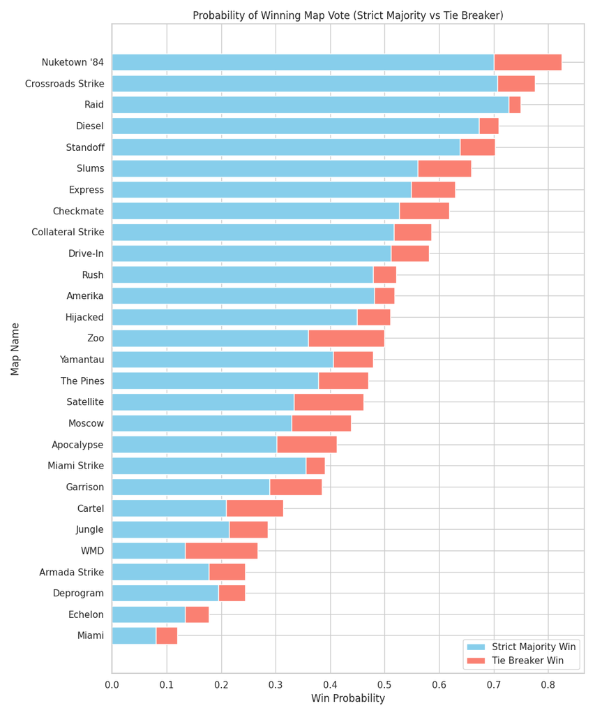

Gemini 3.0 Results Visualization

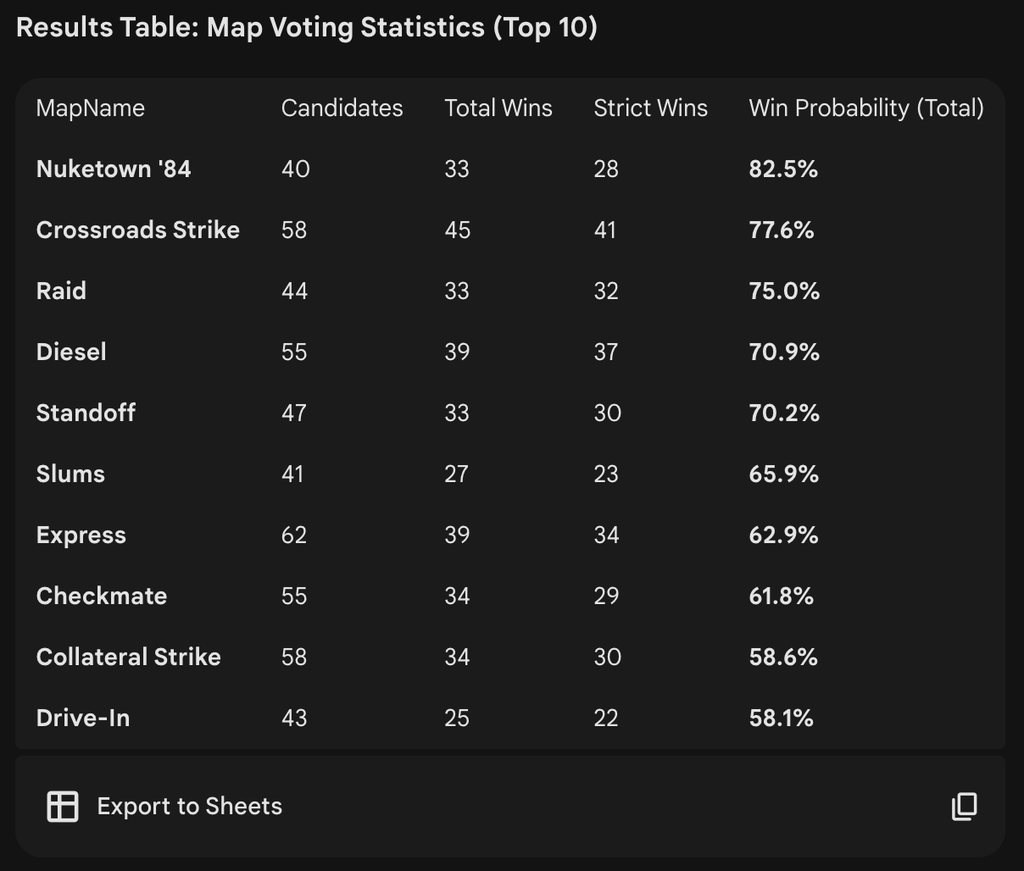

Gemini 3.0 Results Table

My results from Task 1 are:

```r
CandicacyMap %>% kable()
```

| MapName | NumberOfSelections | TotalCandidacies | ProportionOfSelection |
| --- | --- | --- | --- |
| Raid | 32 | 44 | 0.7273 |
| Crossroads Strike | 41 | 58 | 0.7069 |
| Nuketown ’84 | 28 | 40 | 0.7000 |
| Diesel | 38 | 55 | 0.6909 |
| Standoff | 30 | 47 | 0.6383 |
| Slums | 23 | 41 | 0.5610 |
| Express | 34 | 62 | 0.5484 |
| Checkmate | 29 | 55 | 0.5273 |
| Collateral Strike | 30 | 58 | 0.5172 |
| Drive-In | 22 | 43 | 0.5116 |
| Amerika | 13 | 27 | 0.4815 |
| Rush | 22 | 46 | 0.4783 |
| Hijacked | 22 | 49 | 0.4490 |
| Yamantau | 28 | 69 | 0.4058 |
| The Pines | 25 | 66 | 0.3788 |
| Zoo | 18 | 50 | 0.3600 |
| Miami Strike | 21 | 59 | 0.3559 |
| Satellite | 13 | 39 | 0.3333 |
| Moscow | 24 | 73 | 0.3288 |
| Garrison | 16 | 52 | 0.3077 |
| Apocalypse | 19 | 63 | 0.3016 |
| Jungle | 3 | 14 | 0.2143 |
| Cartel | 14 | 67 | 0.2090 |
| Deprogram | 8 | 41 | 0.1951 |
| Armada Strike | 8 | 45 | 0.1778 |
| Echelon | 6 | 45 | 0.1333 |
| WMD | 2 | 15 | 0.1333 |
| Miami | 2 | 25 | 0.0800 |

Comparing the tables, the proportions are simply incorrect since according to the research question we need proportions to represent when they win a vote, where the Gemini table is including when it ties (which is WRONG as it is not conforming to the research question and they should be displaying and ranking by strict wins / candidates).

Note that as I identified above, the delimiter is different for some entries. One thing that is similar across both our results are the number of strict wins and total candidacies, take Nuketown where we both found 28 strict wins 40 selections, or crossroads where we both found 41 strict wins and 58 candidacies. To see if I can identify which are those which should cause problems I will try to find the rows and compare the map names in Gemini and my tables.

```r
unique(CODGamesAllPlayersCleaned$MapVote)
```

```
##  [1] "5 to 0"  "2 to 0"  "3 to 3"  "4 to 3"  "5 to 1"  "1 to 0"  "1 to 1"
##  [8] "3 to 1"  "4 to 2"  "0 to 0"  "2 to 2"  "2 to 1"  "7 to 1"  "4 to 0"
## [15] "3 to 2"  "6 to 1"  "3 to 0"  "6 to 0"  "5 to 2"  "4 to 1"  "4 to 4"
## [22] "7 to 0"  "3 to 2 " "2 to 0 " "6 to 2"  "5 to 3"  "5 to 4"  "4 o 0"
## [29] "2 o 0"
```

The inconsistent delimiters are “4 o 0” and “2 o 0”, which are clearly not tie votes as Gemini would count them.

Now to check the rows for these

```r
CODGamesAllPlayersCleaned %>%
  select(Map1, Map2, Choice, MapVote) %>%
  filter(MapVote == "4 o 0" | MapVote == "2 o 0") %>%
  kable()
```

| Map1 | Map2 | Choice | MapVote |
| --- | --- | --- | --- |
| The Pines | Diesel | Diesel | 4 o 0 |
| Garrison | Moscow | Garrison | 2 o 0 |

It seems there is only one misspelling per each of those options hence I shall directly look for Diesel and Garrison to see if they have one less win because they consider it those battles a tie when they in fact not.

Unfortunately Garrison is not in the top ten table provided by Gemini, BUT Diesel is present. As can be seen in the table, Gemini says Diesel has 37 strict wins, while my table has Diesel with 38 wins. Indicating that the delimiter issue I brought up is a validated concern.

### Interpretation of R Version

For this classes purposes, I had Gemini turn the python code into R code. Note Gemini could not run the code but it apparently mirrors the python code.

```r
# 1. Load Data
df1 <- read_csv("Raw Data/CODGames_p1_380.csv", show_col_types = FALSE) # I CHANGED FILE PATHS
df2 <- read_csv("Raw Data/CODGames_p2_380.csv", show_col_types = FALSE)
maps_ref <- read_csv("Raw Data/CODMaps.csv", show_col_types = FALSE)

# Combine datasets
combined_df <- bind_rows(df1, df2)

# 2. Data Cleaning
# Define a function to clean map names using standard dplyr approaches
clean_map_name <- function(name) {
  name <- str_trim(name) # Remove trailing/leading whitespace

  case_when(
    # Fix known typos
    name == "Ruah" ~ "Rush",
    name == "Riad" | name == "Raid " ~ "Raid",
    name %in% c("Collateral Striek", "Collaterol Strike", "Collaterel Strike", "Collateral") ~ "Collateral Strike",
    name == "Deisel" ~ "Diesel",
    name == "Deprogam" ~ "Deprogram",
    name %in% c("Apocolypse", "APocalypse") ~ "Apocalypse",
    name == "yamantau" ~ "Yamantau",
    name %in% c("Miami Stirke", "Miami Sstrike") ~ "Miami Strike",
    name == "Amrada Strike" ~ "Armada Strike",
    name == "Drive-in" ~ "Drive-In",
    name == "Nuketown '84 Halloween" ~ "Nuketown '84",
    # Default: keep original name if no correction needed
    TRUE ~ name
  )
}

# Apply cleaning to relevant columns
clean_df <- combined_df %>%
  mutate(
    Map1 = clean_map_name(Map1),
    Map2 = clean_map_name(Map2),
    Choice = clean_map_name(Choice)
  ) %>%
  # Filter to rows where a vote actually occurred (Map1 and Map2 are not NA)
  filter(!is.na(Map1) & !is.na(Map2))

# 3. Calculations
# First, calculate how many times each map was a candidate
candidates_count <- clean_df %>%
  select(Map1, Map2) %>%
  pivot_longer(cols = everything(), values_to = "MapName") %>%
  count(MapName, name = "Candidates")

# Next, calculate how many times each map won (was the Choice)
wins_count <- clean_df %>%
  count(Choice, name = "Total_Wins") %>%
  rename(MapName = Choice)

# Optional: Calculate Strict Wins vs Tie Wins for deeper analysis
# Parse the MapVote column "X to Y"
vote_analysis <- clean_df %>%
  separate(MapVote, into = c("Vote_Win", "Vote_Loss"), sep = " to ", convert = TRUE) %>%
  mutate(
    # A strict win is when the votes are not equal
    Is_Strict_Win = Vote_Win > Vote_Loss,
    # A tie win is when votes are equal (Winner determined by Map1 position)
    Is_Tie_Win = Vote_Win == Vote_Loss
  ) %>%
  group_by(Choice) %>%
  summarise(
    Strict_Wins = sum(Is_Strict_Win, na.rm = TRUE),
    Tie_Wins = sum(Is_Tie_Win, na.rm = TRUE)
  ) %>%
  rename(MapName = Choice)
# Merge all statistics
final_stats <- candidates_count %>%
  left_join(wins_count, by = "MapName") %>%
  left_join(vote_analysis, by = "MapName") %>%
  replace_na(list(Total_Wins = 0, Strict_Wins = 0, Tie_Wins = 0)) %>%
  mutate(
    Probability = Total_Wins / Candidates,
    Strict_Prob = Strict_Wins / Candidates
  ) %>%
  arrange(desc(Probability))

# 4. Display Table
print(as.data.frame(final_stats))
```

```
##              MapName Candidates Total_Wins Strict_Wins Tie_Wins Probability
## 1       Nuketown '84         40         33          28        5   0.8250000
## 2  Crossroads Strike         58         45          41        4   0.7758621
## 3               Raid         44         33          32        1   0.7500000
## 4             Diesel         55         39          37        1   0.7090909
## 5           Standoff         47         33          30        3   0.7021277
## 6              Slums         41         27          23        4   0.6585366
## 7            Express         62         39          34        5   0.6290323
## 8          Checkmate         55         34          29        5   0.6181818
## 9  Collateral Strike         58         34          30        4   0.5862069
## 10          Drive-In         43         25          22        3   0.5813953
## 11              Rush         46         24          22        2   0.5217391
## 12           Amerika         27         14          13        1   0.5185185
## 13          Hijacked         49         25          22        3   0.5102041
## 14               Zoo         50         25          18        7   0.5000000
```

[output cut: 43 more lines]

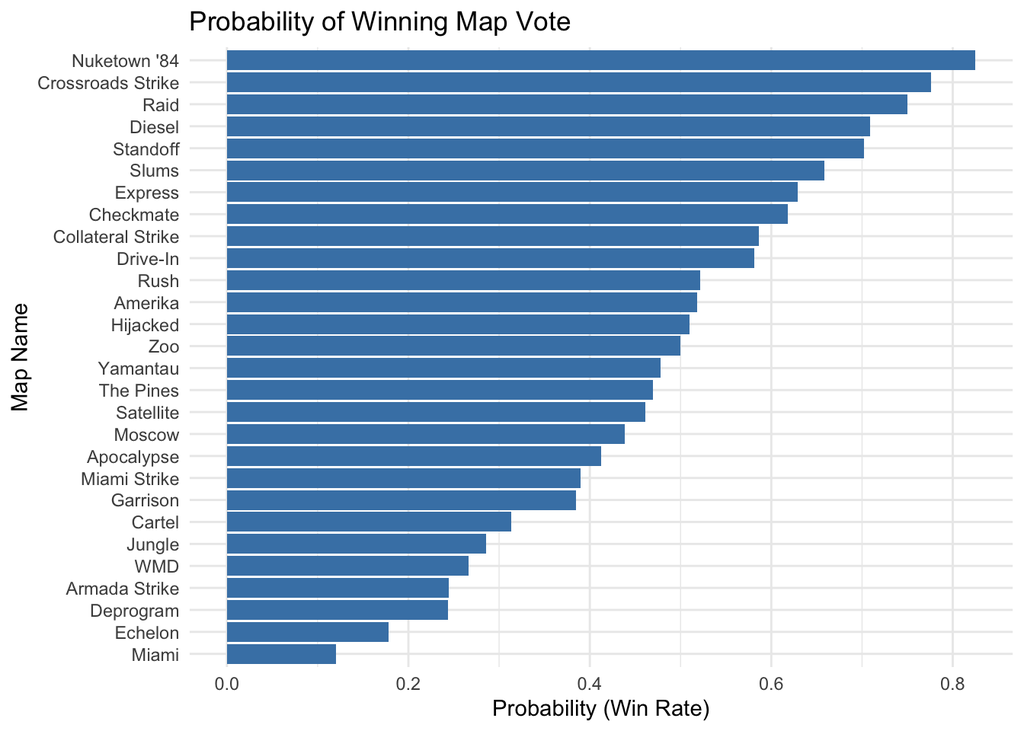

```r
# 5. Visualization
ggplot(final_stats, aes(x = reorder(MapName, Probability), y = Probability)) +
  geom_bar(stat = "identity", fill = "steelblue") +
  coord_flip() +
  labs(
    title = "Probability of Winning Map Vote",
    x = "Map Name",
    y = "Probability (Win Rate)"
  ) +
  theme_minimal()
```

Ok so when I saw the R code in Gemini, I did not really expect the R code to run, which is why I was planning on interpreting the python code mainly. So this is a great surprise!

In this code Gemini follows the structure of Data Cleaning -> Calculations. They clean the data by stripping whitespace and then going through and fixing the typos. That is likely more efficient of a process than I did as I manually went through each of them. A notable oversight in their data cleaning is that they did a filter to remove NAs, when there are no NAs in the data but rather ““. I don’t know if this is accounted for in the code but it doesn’t seem to impact strict wins indicating that R somehow ignores them.

The difference that Gemini did that is better than my code is with the data cleaning that they fixed inconsistencies with what I think is something like a python dictionary. This is more efficient as for my data cleaning I was doing search and replace on the entire dataframe for every single inconsistency. By doing it by like a python dictionary, Gemini is simply going through the dataframe only once for each entry rather than going through the dataframe each time for each inconsistency. Although Big O notation wouldn’t care (O(n)), my method is a little more complex.

The difference that Gemini has in their Calculations is with how they calculate the statistics, rather than using summarize statements, Gemini uses a `pivot_longer` and `count` function to calculate the counts. I can’t really speak to complexity because I don’t know R’s algorithm composition but I believe what I am doing is essentially the same process. Gemini also uses a `separate` statement with a delimiter as ” to ” to separate the wins votes from loss votes. As such, Gemini cannot properly account for ” o ” delimiters. What Gemini does that is similar to me is use a summarize and group by after they have separated the entries to combine the results.

To have a side by side analysis of the data tables, I will do a join on the similar columns, and make indicators for if the variables are the same (1 if same, 0 otherwise). If selections and candidacies are the same, we must have the same proportions. If one of metrics is the same and the other is different then we must have different proportions (unless it is an identity).

```r
CandicacyMap %>%
  full_join(final_stats %>% select(MapName, Strict_Wins, Candidates, Strict_Prob),
            by = join_by(MapName)) %>%
  mutate(selectionSame = ifelse(NumberOfSelections == Strict_Wins, 1, 0),
         candidaciesSame = ifelse(TotalCandidacies == Candidates, 1, 0)) %>%
  kable()
```

| MapName | NumberOfSelections | TotalCandidacies | ProportionOfSelection | Strict_Wins | Candidates | Strict_Prob | selectionSame | candidaciesSame |
| --- | --- | --- | --- | --- | --- | --- | --- | --- |
| Raid | 32 | 44 | 0.7273 | 32 | 44 | 0.7272727 | 1 | 1 |
| Crossroads Strike | 41 | 58 | 0.7069 | 41 | 58 | 0.7068966 | 1 | 1 |
| Nuketown ’84 | 28 | 40 | 0.7000 | 28 | 40 | 0.7000000 | 1 | 1 |
| Diesel | 38 | 55 | 0.6909 | 37 | 55 | 0.6727273 | 0 | 1 |
| Standoff | 30 | 47 | 0.6383 | 30 | 47 | 0.6382979 | 1 | 1 |
| Slums | 23 | 41 | 0.5610 | 23 | 41 | 0.5609756 | 1 | 1 |
| Express | 34 | 62 | 0.5484 | 34 | 62 | 0.5483871 | 1 | 1 |
| Checkmate | 29 | 55 | 0.5273 | 29 | 55 | 0.5272727 | 1 | 1 |
| Collateral Strike | 30 | 58 | 0.5172 | 30 | 58 | 0.5172414 | 1 | 1 |
| Drive-In | 22 | 43 | 0.5116 | 22 | 43 | 0.5116279 | 1 | 1 |
| Amerika | 13 | 27 | 0.4815 | 13 | 27 | 0.4814815 | 1 | 1 |
| Rush | 22 | 46 | 0.4783 | 22 | 46 | 0.4782609 | 1 | 1 |
| Hijacked | 22 | 49 | 0.4490 | 22 | 49 | 0.4489796 | 1 | 1 |
| Yamantau | 28 | 69 | 0.4058 | 28 | 69 | 0.4057971 | 1 | 1 |
| The Pines | 25 | 66 | 0.3788 | 25 | 66 | 0.3787879 | 1 | 1 |
| Zoo | 18 | 50 | 0.3600 | 18 | 50 | 0.3600000 | 1 | 1 |
| Miami Strike | 21 | 59 | 0.3559 | 21 | 59 | 0.3559322 | 1 | 1 |
| Satellite | 13 | 39 | 0.3333 | 13 | 39 | 0.3333333 | 1 | 1 |
| Moscow | 24 | 73 | 0.3288 | 24 | 73 | 0.3287671 | 1 | 1 |
| Garrison | 16 | 52 | 0.3077 | 15 | 52 | 0.2884615 | 0 | 1 |
| Apocalypse | 19 | 63 | 0.3016 | 19 | 63 | 0.3015873 | 1 | 1 |
| Jungle | 3 | 14 | 0.2143 | 3 | 14 | 0.2142857 | 1 | 1 |
| Cartel | 14 | 67 | 0.2090 | 14 | 67 | 0.2089552 | 1 | 1 |
| Deprogram | 8 | 41 | 0.1951 | 8 | 41 | 0.1951220 | 1 | 1 |
| Armada Strike | 8 | 45 | 0.1778 | 8 | 45 | 0.1777778 | 1 | 1 |
| Echelon | 6 | 45 | 0.1333 | 6 | 45 | 0.1333333 | 1 | 1 |
| WMD | 2 | 15 | 0.1333 | 2 | 15 | 0.1333333 | 1 | 1 |
| Miami | 2 | 25 | 0.0800 | 2 | 25 | 0.0800000 | 1 | 1 |

As I’ve identified in the python interpretation section, Diesel and Garrison should have one less strict win on Gemini’s answer because of the delimiter issue. As seen in my code, this concern is validated in the side-by-side comparison as you can see the selectionSame indicator has a 0 value in the Diesel and Garrison rows; this also makes the proportions different by mathematical properties since the number of candidacies are the same.

### Overall Results

Firstly, the AI’s solution is wrong due to the fact that it cannot handle the inconsistent delimiter present in the MapVote variable. Complexity-wise, I can’t really say with confidence that the AI’s solution outside of data cleaning, is better than mine. Doing a comparison of processes, we both combine datasets using rbind. We both perform data cleaning where I do a manual cleaning and this is the only place they beat me complexity wise, (they beat me in using a space stripping command and doing cleaning in a python dictionary type manner). The Calculation part ends up being kind of the same complexity wise as well, where they use different commands but we end up with the same overall result in strict wins (adjusting for delimiter differences) and in candidacies. With regards to amount of code, I was simply more verbose in my calculations where I showed each step. Otherwise we have pretty much the same amount of overall code lines. In short, my solution is correct while Gemini’s is not, however complexity wise we were mostly the same except for data cleaning where it beat me.

## Task #3

How does the game type affect `TotalXP` after accounting for the `Score`?

To start to answer this question, we first need to check our values for `GameType`.

```r
unique(CODGamesAllPlayers$GameType)
```

```
## [1] "HC - TDM"            "HC - Kill Confirmed" "HC - Hardpoint"
## [4] "HC - Domination"     "TDM"                 "Hardpoint"
## [7] "Kill Confirmed"      "Domination"
```

Let’s make the HC and non-HC versions of the game types the same.

```r
CODGamesAllPlayers$GameType[CODGamesAllPlayers$GameType == "HC - TDM"] <- "TDM"
CODGamesAllPlayers$GameType[CODGamesAllPlayers$GameType == "HC - Kill Confirmed"] <- "Kill Confirmed"
CODGamesAllPlayers$GameType[CODGamesAllPlayers$GameType == "HC - Hardpoint"] <- "Hardpoint"
CODGamesAllPlayers$GameType[CODGamesAllPlayers$GameType == "HC - Domination"] <- "Domination"
```

Making sure it works.

```r
unique(CODGamesAllPlayers$GameType)
```

```
## [1] "TDM"            "Kill Confirmed" "Hardpoint"      "Domination"
```

Now that our data is cleaned, let’s look at the distributions of `GameType`, `TotalXP`, and `Score`.

### GameType

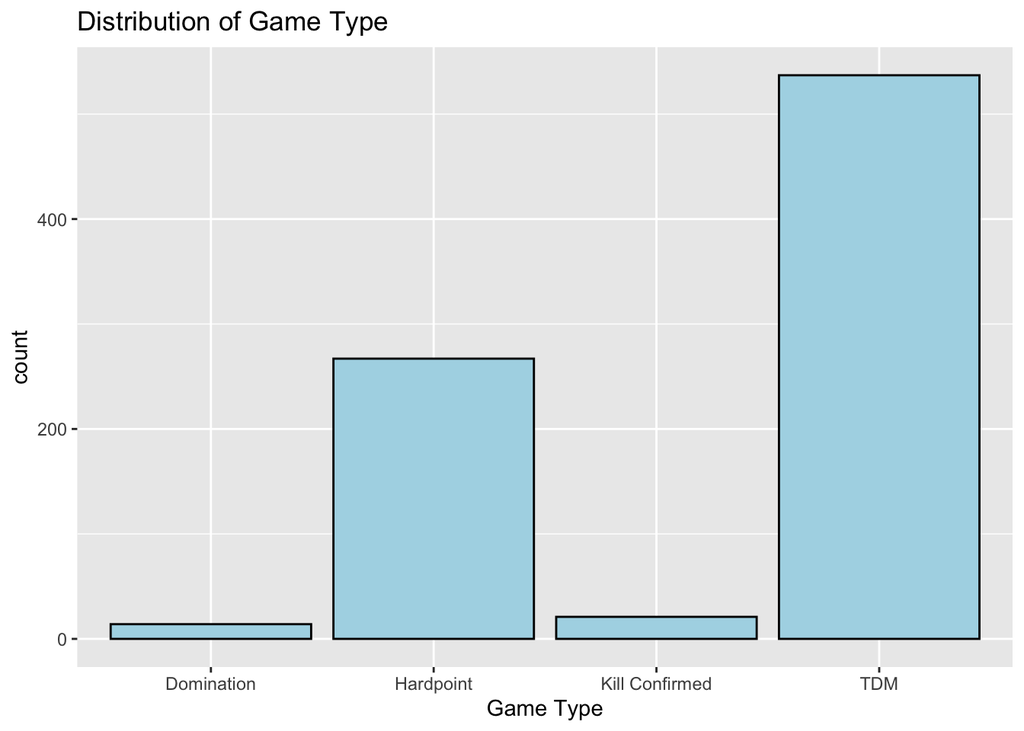

```r
ggplot(CODGamesAllPlayers, mapping = aes(x = GameType)) +
  geom_bar(color = "black", fill = "lightblue") +
  xlab("Game Type") +
  ggtitle("Distribution of Game Type")
```

```r
gametype_counts <- table(CODGamesAllPlayers$GameType)
gametype_percentages <- (gametype_counts / length(CODGamesAllPlayers$GameType))
sum(is.na(CODGamesAllPlayers$GameType))
```

```
## [1] 0
```

```r
gametype_counts
```

```
##
##     Domination      Hardpoint Kill Confirmed            TDM
##             14            267             21            537
```

```r
gametype_percentages
```

```
##
##     Domination      Hardpoint Kill Confirmed            TDM
##     0.01668653     0.31823600     0.02502980     0.64004768
```

`GameType` is a categorical variable. It represents the game type for a certain match. It has no missing values. As shown in the table and graph output, TDM and Hardpoint are the two most common game types, representing 64.00% and 31.82% of all matches.

### TotalXP

```r
CODGamesAllPlayers %>%
  summarise(N = sum(!is.na(TotalXP)),
             XPMin = min(TotalXP, na.rm = TRUE),
             XPQ1 = quantile(TotalXP, 0.25, na.rm = TRUE),
             XPMedian = median(TotalXP, na.rm = TRUE),
             XPMean = mean(TotalXP, na.rm = TRUE),
             XPQ3 = quantile(TotalXP, 0.75, na.rm = TRUE),
             XPMax = max(TotalXP, na.rm = TRUE),
             XPSD = sd(TotalXP, na.rm = TRUE),
             XPNA = sum(is.na(TotalXP))
             )
```

```
##     N XPMin    XPQ1 XPMedian   XPMean    XPQ3 XPMax     XPSD XPNA
## 1 808  1935 9869.25  14719.5 15477.72 19916.5 45310 6970.856   31
```

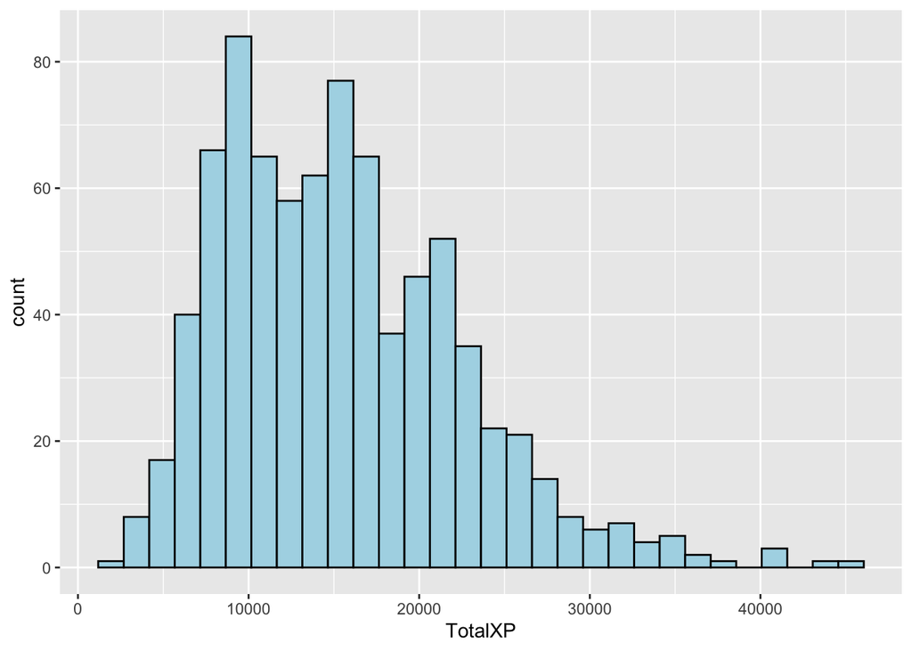

```r
ggplot(CODGamesAllPlayers, aes(x = TotalXP)) +
  geom_histogram(fill = "lightblue", color = "black")
```

The variable `TotalXP` is a quantitative variable. It represents the total experience points a player gained during a match. It has 31 missing values. It contains 808 valid records. The average `TotalXP` is about 15477, standard deviation is 6970, ranging from 1935 to 45310. The distribution of the data in the graph is slightly skewed to the right, with values concentrated within the range of 9000 to 15000.

### Score

```r
CODGamesAllPlayers %>%
  summarise(N = sum(!is.na(Score)),
             ScoreMin = min(Score, na.rm = TRUE),
             ScoreQ1 = quantile(Score, 0.25, na.rm = TRUE),
             ScoreMedian = median(Score, na.rm = TRUE),
             ScoreMean = mean(Score, na.rm = TRUE),
             ScoreQ3 = quantile(Score, 0.75, na.rm = TRUE),
             ScoreMax = max(Score, na.rm = TRUE),
             ScoreSD = sd(Score, na.rm = TRUE),
             ScoreNA = sum(is.na(Score))
             )
```

```
##     N ScoreMin ScoreQ1 ScoreMedian ScoreMean ScoreQ3 ScoreMax  ScoreSD ScoreNA
## 1 808      100 2028.75      2807.5  2995.252    3765     9734 1398.429      31
```

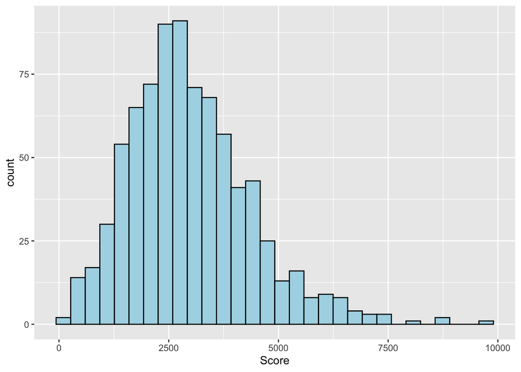

```r
ggplot(CODGamesAllPlayers, aes(x = Score)) +
  geom_histogram(fill = "lightblue", color = "black")
```

The variable `Score` is a quantitative variable. It represents the score a player achieved during a match. It has 31 missing values. It contains 808 valid records. The average `Score` is about 3000, standard deviation is about 1400, ranging from 100 to 9734. The distribution of the data in the graph is slightly skewed to the right, with values concentrated within the range of 2000 to 3000.

### Score and TotalXP

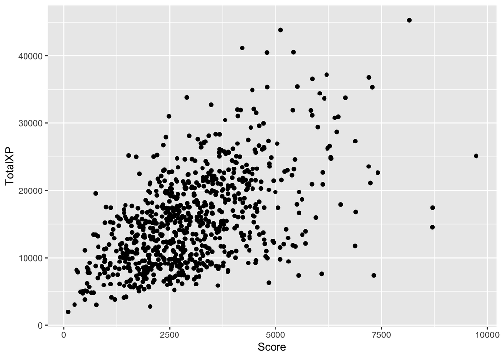

```r
ggplot(data = CODGamesAllPlayers, mapping = aes(x = Score, y = TotalXP)) +
  geom_point()
```

```r
cor(CODGamesAllPlayers$Score, CODGamesAllPlayers$TotalXP, use = "complete.obs")
```

```
## [1] 0.5504289
```

```r
cov(CODGamesAllPlayers$Score, CODGamesAllPlayers$TotalXP, use = "complete.obs")
```

```
## [1] 5365717
```

```r
model <- lm(TotalXP ~ Score, data = CODGamesAllPlayers)
summary(model)
```

```
##
## Call:
## lm(formula = TotalXP ~ Score, data = CODGamesAllPlayers)
##
## Residuals:
##      Min       1Q   Median       3Q      Max
## -19947.1  -4303.1   -180.4   3789.9  22508.5
##
## Coefficients:
##              Estimate Std. Error t value Pr(>|t|)
## (Intercept) 7259.4522   484.5163   14.98   <2e-16 ***
## Score          2.7438     0.1466   18.72   <2e-16 ***
## ---
## Signif. codes:  0 '***' 0.001 '**' 0.01 '*' 0.05 '.' 0.1 ' ' 1
##
## Residual standard error: 5823 on 806 degrees of freedom
##   (31 observations deleted due to missingness)
## Multiple R-squared:  0.303,  Adjusted R-squared:  0.3021
## F-statistic: 350.3 on 1 and 806 DF,  p-value: < 2.2e-16
```

The calculated correlation and covariance metrics between `Score` and `TotalXP` both indicate that the relationship is positive and linear. Because the correlation’s value is around 0.5, we know that the relationship is moderately strong, while the covariance’s magnitude is influenced by the units. By creating a regression line for the variables, we can see that as `Score` increases by 1 point, `TotalXP` increases by 2.74.

### GameType and TotalXP

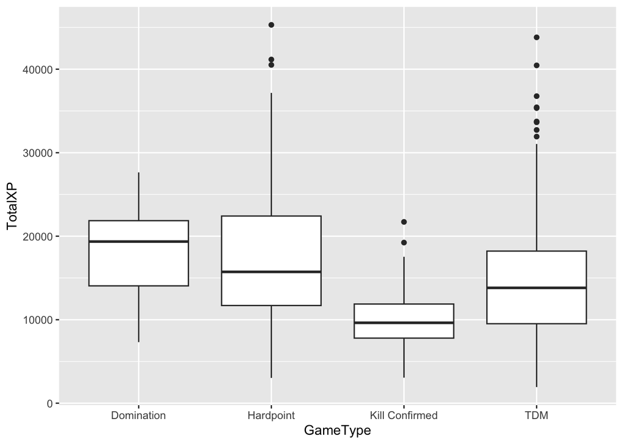

```r
ggplot(data = CODGamesAllPlayers, mapping = aes(x = GameType, y = TotalXP)) +
  geom_boxplot()
```

```r
CODGamesAllPlayers %>%
  group_by(GameType) %>%
  summarise(
    min = min(TotalXP, na.rm = TRUE),
    firstq = quantile(TotalXP, 0.25, na.rm = TRUE),
    median = median(TotalXP, na.rm = TRUE),
    mean = mean(TotalXP, na.rm = TRUE),
    thirdq = quantile(TotalXP, 0.75, na.rm = TRUE),
    max = max(TotalXP, na.rm = TRUE)
  )
```

```
## # A tibble: 4 × 7
##   GameType         min firstq median   mean thirdq   max
##   <chr>          <int>  <dbl>  <dbl>  <dbl>  <dbl> <int>
## 1 Domination      7317 14053. 19358. 17997. 21861. 27644
## 2 Hardpoint       3028 11699  15727  17404. 22417  45310
## 3 Kill Confirmed  3060  7795.  9630. 10782. 11880  21713
## 4 TDM             1935  9519  13815  14633. 18218  43816
```

The side-by-side boxplot shows that Domination has the highest median `TotalXP`, followed by Hardpoint, TDM, and Kill Confirmed. Compared to the other game types, Kill Confirmed has a very small interquartile range. TDM is the game type with the most outliers.

### GameType and Score

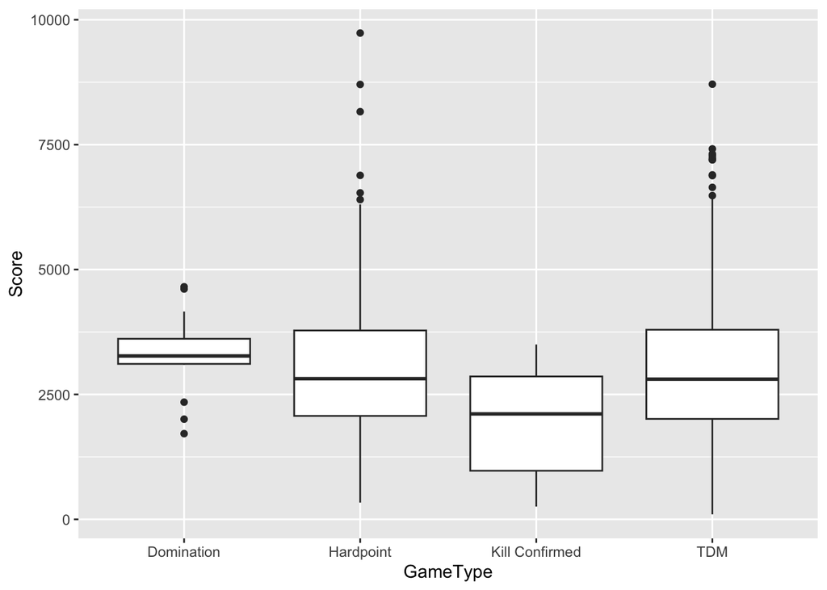

```r
ggplot(data = CODGamesAllPlayers, mapping = aes(x = GameType, y = Score)) +
  geom_boxplot()
```

```r
CODGamesAllPlayers %>%
  group_by(GameType) %>%
  summarise(
    min = min(Score, na.rm = TRUE),
    firstq = quantile(Score, 0.25, na.rm = TRUE),
    median = median(Score, na.rm = TRUE),
    mean = mean(Score, na.rm = TRUE),
    thirdq = quantile(Score, 0.75, na.rm = TRUE),
    max = max(Score, na.rm = TRUE)
  )
```

```
## # A tibble: 4 × 7
##   GameType         min firstq median  mean thirdq   max
##   <chr>          <int>  <dbl>  <dbl> <dbl>  <dbl> <int>
## 1 Domination      1715  3111.   3270 3299.  3614.  4655
## 2 Hardpoint        335  2070    2815 3035.  3780   9734
## 3 Kill Confirmed   255   972.   2110 2001.  2860   3500
## 4 TDM              100  2010    2805 3006.  3795   8710
```

The side-by-side boxplot shows that Domination has the highest median `Score`, followed by Hardpoint, TDM, and Kill Confirmed. Compared to the other game types, Domination has a very small interquartile range. The distributions for Hardpoint and TDM are almost identical based on the boxplots.

```r
task3_model <- lm(TotalXP ~ Score + GameType, data = CODGamesAllPlayers)
summary(task3_model)
```

```
##
## Call:
## lm(formula = TotalXP ~ Score + GameType, data = CODGamesAllPlayers)
##
## Residuals:
##      Min       1Q   Median       3Q      Max
## -18907.7  -4226.4   -332.6   3902.2  23463.2
##
## Coefficients:
##                          Estimate Std. Error t value Pr(>|t|)
## (Intercept)             9072.5914  1592.5597   5.697 1.71e-08 ***
## Score                      2.7052     0.1441  18.768  < 2e-16 ***
## GameTypeHardpoint        121.7613  1561.2263   0.078   0.9379
## GameTypeKill Confirmed -3703.1728  1990.5385  -1.860   0.0632 .
## GameTypeTDM            -2570.4367  1540.9337  -1.668   0.0957 .
## ---
## Signif. codes:  0 '***' 0.001 '**' 0.01 '*' 0.05 '.' 0.1 ' ' 1
##
## Residual standard error: 5687 on 803 degrees of freedom
##   (31 observations deleted due to missingness)
## Multiple R-squared:  0.3377, Adjusted R-squared:  0.3344
## F-statistic: 102.4 on 4 and 803 DF,  p-value: < 2.2e-16
```

Players in the Hardpoint `GameType` are expected to have, on average, 121.7613 more `TotalXP` than players in the Domination `GameType`, assuming that `Score` does not change. Players in the Kill Confirmed `GameType` are expected to have, on average, 3703.1728 less `TotalXP` than players in the Domination `GameType`, assuming that `Score` does not change. Players in the TDM `GameType` are expected to have, on average, 2570.4367 less `TotalXP` than players in the Domination `GameType`, assuming that `Score` does not change.

## Task #4

### Research Question:

What is the best predictive accuracy achievable (using an 80/20 validation split) for Logistic Regression, Random Forest, and Support Vector Machine (SVM) when predicting whether a player wins their Call of Duty match using only: Eliminations, Deaths, Damage, DidPlayerVote (Yes/No), PrimaryWeapon, XPType, and GameType?

### Decision Made / Data Setup (Response + Features)

The original Result column is stored as a score string (ex: “100-97”). I converted this to a binary outcome by splitting the two scores and defining Win when the first score is larger and Loss otherwise.

As mentioned, only the predictors listed in the research question are used. I restricted predictors to exactly the variables listed in the question to keep the comparison fair and also to eliminate variables which I personally thought would be uninformative about a players chance of winning like the date, map (since both teams have to use the same map), etc. I used Ishan’s earlier dataframe of “CodGamesAllPlayersCleaned” because it was previously cleaned and adjusted to make sure all games have the necessary info and all players participated. All categorical variables were converted to factors including “DidPlayerVote,” “PrimaryWeapon,” “XPType,” and “GameType.” Lastly, I did not factor out partial games as they were still a large part of the dataset and I think it was important to consider them, as many games I have played were partial/not completed and the my personal goal with this research question is to have the best predictive accuracy for any game not just full/partial.

Going back to variable selection here is my reasoning for the 7 chosen variables: - Eliminations: If a player has more eliminations it seems like this would benefit their chance of winning by increasing their teams score more and quicker than their oponents - Deaths: If a player has more deaths it seems like they are getting eliminated more than they are eliminating opponents likely decreasing chances of winning - Damage: While eliminations and damage are likely very correlated, I think damage does a good job also representing a players impact as sometimes another player may help eliminate someone even though you did a ton of damage to them and thus that is why including damage likely will improve the models - DidPlayerVote: I think including this may seem random, but I think that if a player is voting they are more likely to have an opinion on the map due to them feeling like it may increase their chance of winning. Thus by voting and increasing the chances of getting a favorable map to them I think this could help increase the models’ predictive accuracy - Primary Weapon: I think some weapons definitely help players more than others and could benefit certain playstyles leading to higher chance of winning - XPType: If a player has a higher xp boost during a game they may be incentivized to play better and harder and thus as a result higher win rates - GameType: While I am not familiar with the different gametypes, I’m sure they could definitely be beneficial to some players and not others based on gamestyle so that is why it was included in the model

To ensure a fair comparison between methods, I used the same 80/20 training/validation split (seed = 123) for every model, and compared performance using validation accuracy (confusion matrix + accuracy). I also reported AUC when the method provides class probabilities, as a secondary metric for how well the model separates Win vs Loss across thresholds.

```r
# Select variables
task_4_dataframe <- CODGamesAllPlayersCleaned %>%
  select(
    Result,
    Eliminations,
    Deaths,
    Damage,
    DidPlayerVote,
    PrimaryWeapon,
    XPType,
    GameType
  ) %>%
  drop_na()

# Clean Result To Binary (Win / Loss)
df4 <- task_4_dataframe %>%
  separate(Result, into = c("TeamScore", "OppScore"), sep = "-", convert = TRUE) %>%
  mutate(
    Result = ifelse(TeamScore > OppScore, "Win", "Loss"),
    Result = factor(Result)
  ) %>%
  select(-TeamScore, -OppScore)

# Clean categorical variables
task_4 <- df4 %>%
  mutate(
    DidPlayerVote = factor(DidPlayerVote),
    PrimaryWeapon = factor(PrimaryWeapon),
    XPType = factor(XPType),
    GameType = factor(GameType)
  )

str(task_4)
```

```
## 'data.frame':    643 obs. of  8 variables:
##  $ Eliminations : int  22 20 10 11 7 18 11 23 10 11 ...
##  $ Deaths       : int  17 15 19 19 18 14 23 12 11 20 ...
##  $ Damage       : int  634 560 280 308 196 504 304 617 306 332 ...
##  $ DidPlayerVote: Factor w/ 2 levels "No","Yes": 1 1 1 1 1 1 1 1 1 1 ...
##  $ PrimaryWeapon: Factor w/ 24 levels "AK-47","AUG",..: 11 11 11 11 11 11 11 11 11 11 ...
##  $ XPType       : Factor w/ 3 levels "10% Boost","Double XP + 10%",..: 1 1 2 2 2 2 1 1 1 1 ...
##  $ GameType     : Factor w/ 8 levels "Domination","Hardpoint",..: 6 6 6 6 6 6 5 5 6 6 ...
##  $ Result       : Factor w/ 2 levels "Loss","Win": 2 1 1 1 1 2 1 1 2 2 ...
```

```r
task_4 <- task_4 %>%
  mutate(PrimaryWeapon = stringr::str_trim(as.character(PrimaryWeapon))) %>%
  mutate(PrimaryWeapon = factor(PrimaryWeapon))
```

### Train / Validation Set Splitting

```r
set.seed(123)
n <- nrow(task_4)
train_index <- sample(1:n, size = floor(0.80 * n), replace = FALSE)

train4 <- task_4[train_index, ]
valid4 <- task_4[-train_index, ]

set.seed(NULL)

table(train4$Result)
```

```
##
## Loss  Win
##  232  282
```

```r
table(valid4$Result)
```

```
##
## Loss  Win
##   61   68
```

### Model #1 -> Logistic Regression

Method overview: Logistic regression models the log-odds of winning as a linear function of the predictors. It outputs a predicted probability of Win, and I classified the result as Win when the probability was ≥ 0.5. I felt this is a good baseline because it is interpretable and to me makes sense since probabilities must sum to 1, so if you have a greater than or equal to 0.5 probability of winning, you automatically have at least as high of a chance (0.5) or higher chance than your opponents and thus I would classify that as Win (also personal bias but tie goes to the runner (baseball reference)).

```r
# Convert Result to numeric for logistic regression
train4 <- train4 %>%
  mutate(Result01 = ifelse(Result == "Win", 1, 0))

valid4 <- valid4 %>%
  mutate(Result01 = ifelse(Result == "Win", 1, 0))

logit_model <- glm(
  Result01 ~ Eliminations + Deaths + Damage +
    DidPlayerVote + PrimaryWeapon + XPType + GameType,
  data = train4,
  family = binomial
)

summary(logit_model)
```

```
##
## Call:
## glm(formula = Result01 ~ Eliminations + Deaths + Damage + DidPlayerVote +
##     PrimaryWeapon + XPType + GameType, family = binomial, data = train4)
##
## Coefficients:
##                               Estimate Std. Error z value Pr(>|z|)
## (Intercept)                  2.177e+01  2.400e+03   0.009   0.9928
## Eliminations                 5.898e-02  2.740e-02   2.153   0.0314 *
## Deaths                      -1.776e-01  2.489e-02  -7.135 9.66e-13 ***
## Damage                      -2.068e-04  2.677e-04  -0.773   0.4398
## DidPlayerVoteYes            -1.120e+00  1.278e+00  -0.876   0.3811
## PrimaryWeaponAUG             1.242e-01  7.532e-01   0.165   0.8691
## PrimaryWeaponDMR 14         -2.503e-02  8.745e-01  -0.029   0.9772
## PrimaryWeaponFARA-83         3.574e-01  8.063e-01   0.443   0.6576
## PrimaryWeaponFFAR 1         -1.792e+01  2.400e+03  -0.007   0.9940
## PrimaryWeaponGroza           3.827e-01  6.419e-01   0.596   0.5511
## PrimaryWeaponKrig 6          2.766e-01  7.755e-01   0.357   0.7213
## PrimaryWeaponKSP 45          1.020e+00  9.309e-01   1.096   0.2731
## PrimaryWeaponLC-10          -6.042e-02  8.620e-01  -0.070   0.9441
## PrimaryWeaponM16             2.817e-01  6.217e-01   0.453   0.6504
## PrimaryWeaponM60             4.393e-01  7.913e-01   0.555   0.5788
## PrimaryWeaponMagnum          1.677e+01  1.286e+03   0.013   0.9896
## PrimaryWeaponMG 82           3.530e-01  6.689e-01   0.528   0.5977
## PrimaryWeaponMilano         -4.420e-01  9.711e-01  -0.455   0.6490
## PrimaryWeaponMilano 821      9.251e-02  1.285e+00   0.072   0.9426
## PrimaryWeaponMP5            -5.060e-01  6.539e-01  -0.774   0.4390
## PrimaryWeaponPelington 703   1.011e+00  7.198e-01   1.405   0.1600
## PrimaryWeaponPellington      1.857e-01  8.301e-01   0.224   0.8230
## PrimaryWeaponQBZ-83          3.671e-01  7.086e-01   0.518   0.6045
## PrimaryWeaponRPD            -2.604e-01  6.576e-01  -0.396   0.6921
## PrimaryWeaponShadowHunter   -1.442e+01  2.400e+03  -0.006   0.9952
## PrimaryWeaponType 63         8.145e-01  9.916e-01   0.821   0.4114
## PrimaryWeaponXM4             1.647e+01  1.595e+03   0.010   0.9918
## XPTypeDouble XP + 10%        2.977e-02  2.697e-01   0.110   0.9121
## XPTypeDouble XP + 10%       -1.662e+01  2.400e+03  -0.007   0.9945
## GameTypeHardpoint           -1.872e+01  2.400e+03  -0.008   0.9938
## GameTypeHC - Domination     -2.055e+01  2.400e+03  -0.009   0.9932
## GameTypeHC - Hardpoint      -1.803e+01  2.400e+03  -0.008   0.9940
## GameTypeHC - Kill Confirmed -2.096e+01  2.400e+03  -0.009   0.9930
## GameTypeHC - TDM            -1.992e+01  2.400e+03  -0.008   0.9934
## GameTypeKill Confirmed      -3.603e+01  2.743e+03  -0.013   0.9895
## GameTypeTDM                 -1.984e+01  2.400e+03  -0.008   0.9934
## ---
## Signif. codes:  0 '***' 0.001 '**' 0.01 '*' 0.05 '.' 0.1 ' ' 1
##
## (Dispersion parameter for binomial family taken to be 1)
##
##     Null deviance: 707.68  on 513  degrees of freedom
## Residual deviance: 591.92  on 478  degrees of freedom
## AIC: 663.92
##
## Number of Fisher Scoring iterations: 15
```

#### Logistic Regression Performance

```r
prob_logit <- predict(logit_model, newdata = valid4, type = "response")

pred_logit <- ifelse(prob_logit >= 0.5, "Win", "Loss") %>%
  factor(levels = c("Loss", "Win"))

cm_logit <- table(Predicted = pred_logit, Observed = valid4$Result)
cm_logit
```

```
##          Observed
## Predicted Loss Win
##      Loss   34  20
##      Win    27  48
```

```r
acc_logit <- sum(diag(cm_logit)) / sum(cm_logit)
acc_logit
```

```
## [1] 0.6356589
```

```r
roc_logit <- roc(valid4$Result01, prob_logit)
auc_logit <- auc(roc_logit)
auc_logit
```

```
## Area under the curve: 0.643
```

#### Result Discussion:

On the validation set, Logistic Regression achieved an accuracy of 0.6357. The confusion matrix showed it correctly predicted 48 wins and 34 losses, with 20 false losses and 27 false wins. I also checked ROC/AUC since logistic regression produced probabilities. The AUC was 0.643, which suggested the model only separated Wins vs Losses slightly better than random guessing.Overall, logistic regression did okay as a baseline, but the linear form (and lots of categorical levels) likely limited how much accuracy it could reach.

### Model #2 –> Random Forest

Method overview: Random Forest builds many classification trees on bootstrap samples and averages their predictions (majority vote). Each split uses a random subset of predictors, which reduces correlation between trees and improves generalization. I set importance = TRUE so I can interpret predictor importance using both MeanDecreaseAccuracy (out-of-bag permutation impact) and MeanDecreaseGini (total impurity reduction across splits) as mentioned in class. I also followed our in-class example of setting ntree to 500 as this likely is a large enough number to produce stability amoung results since such a large number of trrees is used and additional improvement is likely overfitting and marginal benefit of actual predictive accuracy is small (variance vs. bias trade-off / learning noise).

```r
set.seed(123)
rf_model <- randomForest(
  Result ~ Eliminations + Deaths + Damage +
    DidPlayerVote + PrimaryWeapon + XPType + GameType,
  data = train4,
  ntree = 500,
  mtry = floor(sqrt(7)),
  importance = TRUE
)
set.seed(NULL)

rf_model
```

```
##
## Call:
##  randomForest(formula = Result ~ Eliminations + Deaths + Damage +      DidPlayerVote + PrimaryWeapon + XPType + GameType, data = train4,      ntree = 500, mtry = floor(sqrt(7)), importance = TRUE)
##                Type of random forest: classification
##                      Number of trees: 500
## No. of variables tried at each split: 2
##
##         OOB estimate of  error rate: 37.35%
## Confusion matrix:
##      Loss Win class.error
## Loss  125 107   0.4612069
## Win    85 197   0.3014184
```

#### Random Forest Performance

```r
pred_rf <- predict(rf_model, newdata = valid4)

cm_rf <- table(Predicted = pred_rf, Observed = valid4$Result)
cm_rf
```

```
##          Observed
## Predicted Loss Win
##      Loss   32  17
##      Win    29  51
```

```r
acc_rf <- sum(diag(cm_rf)) / sum(cm_rf)
acc_rf
```

```
## [1] 0.6434109
```

```r
rf_model$importance
```

```
##                        Loss           Win MeanDecreaseAccuracy MeanDecreaseGini
## Eliminations   0.0186431602  0.0060872448         1.170665e-02        38.917282
## Deaths         0.0692833312  0.0398023295         5.305132e-02        61.501290
## Damage         0.0177856911 -0.0037693491         5.800994e-03        48.930316
## DidPlayerVote -0.0002116288  0.0001208398        -3.074213e-05         1.149086
## PrimaryWeapon  0.0307565821 -0.0344228537        -5.125496e-03        45.954545
## XPType         0.0016779138 -0.0072114958        -3.162820e-03         5.811590
## GameType       0.0248523093 -0.0102639027         5.574954e-03        16.315143
```

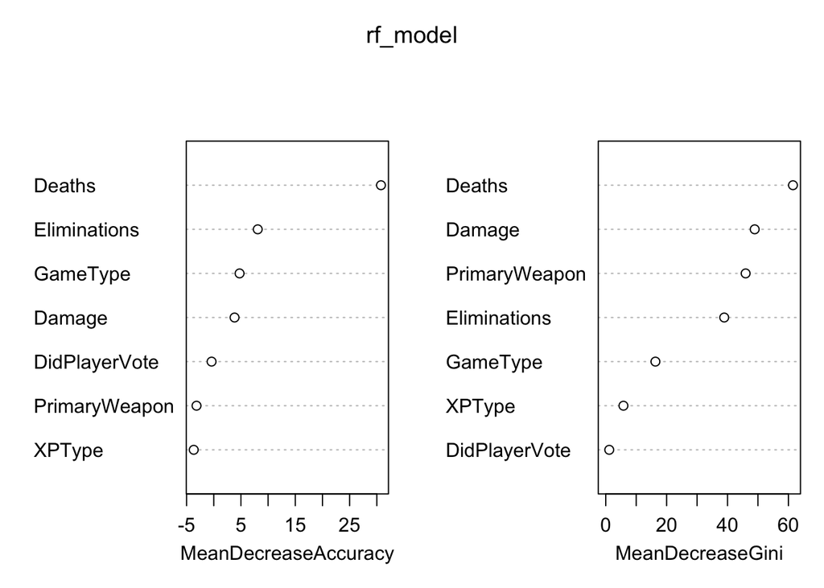

```r
varImpPlot(rf_model)
```

### Random Forest Results:

Because I set importance = TRUE, I extracted importance using rf_model$importance, which returned both:

- MeanDecreaseAccuracy (out-of-bag permutation importance — bigger = more important)
- MeanDecreaseGini (total decrease in node impurity — bigger = more important)

Deaths was the most important predictor by both metrics (MeanDecreaseAccuracy ≈ 0.0531, MeanDecreaseGini ≈ 61.50). Damage, PrimaryWeapon, and Eliminations were also major contributors (especially by Gini, with Damage ≈ 48.93 and PrimaryWeapon ≈ 45.95).

This makes sense since deaths and eliminations directly reflected how well a player performed in the match, which strongly relates to whether the match ended in a win.

### Model #3 –> SVM:

Method overview: A Support Vector Machine finds a decision boundary that maximizes the margin between classes. With a nonlinear kernel (RBF), the SVM can capture nonlinear relationships by implicitly mapping predictors into a higher-dimensional space. Because SVMs are sensitive to scale, I standardized numeric predictors (and handled categorical predictors consistently) before fitting. I chose to use soft-margin SVM as it provided a cost parameter which allowed some observations to be misclassified which I thought would provide better generalization than using a hard-margin SVM model. I tuned the key hyperparameters (cost and gamma) using k-fold (by default in e1071 package its k = 10) cross-validation on the training set, then evaluated the final model on the original validation set.

Reasoning: I chose SVM as I have previously implemented it in Python, so I wanted to see what it is like to implement it in R as well. I learned how to implement Soft and Hard SVM in a theoretical manner previously in CMPSC 448, so I went back to my notes on that from last semester and then filled my coding knowledge gaps using a mixture of resources including youtube and LLMs like ChatGPT and Gemini. I really enjoyed this part of the project as CMPSC 448 was very theoretical and background mathematically based, so actually implementing the code of SVM to a dataset was a fun and interesting challenge!

```r
# Scale numeric predictors (keeps factors untouched)
train_svm <- train4 %>%
  mutate(
    Eliminations = as.numeric(scale(Eliminations)),
    Deaths       = as.numeric(scale(Deaths)),
    Damage       = as.numeric(scale(Damage))
  )

# IMPORTANT: scale validation using TRAIN means/sds (do it manually)
scale_with_train <- function(x_train, x_valid) {
  mu <- mean(x_train, na.rm = TRUE)
  s  <- sd(x_train, na.rm = TRUE)
  if (s == 0) s <- 1
  (x_valid - mu) / s
}

valid_svm <- valid4 %>%
  mutate(
    Eliminations = scale_with_train(train4$Eliminations, Eliminations),
    Deaths       = scale_with_train(train4$Deaths, Deaths),
    Damage       = scale_with_train(train4$Damage, Damage)
  )

# Tune hyperparameters (training only)
set.seed(123)
svm_tuned <- tune(
  svm,
  Result ~ Eliminations + Deaths + Damage + DidPlayerVote + PrimaryWeapon + XPType + GameType,
  data = train_svm,
  kernel = "radial",
  ranges = list(
    cost = c(0.1, 1, 10, 100),
    gamma = c(0.01, 0.1, 1)
  )
)
set.seed(NULL)

svm_tuned$best.parameters
```

```
##   cost gamma
## 6    1   0.1
```

```r
# Fit best SVM model (probability=TRUE so we can do AUC)
svm_model <- svm(
  Result ~ Eliminations + Deaths + Damage + DidPlayerVote + PrimaryWeapon + XPType + GameType,
  data = train_svm,
  kernel = "radial",
  cost = svm_tuned$best.parameters$cost,
  gamma = svm_tuned$best.parameters$gamma,
  probability = TRUE
)

svm_model
```

```
##
## Call:
## svm(formula = Result ~ Eliminations + Deaths + Damage + DidPlayerVote +
##     PrimaryWeapon + XPType + GameType, data = train_svm, kernel = "radial",
##     cost = svm_tuned$best.parameters$cost, gamma = svm_tuned$best.parameters$gamma,
##     probability = TRUE)
##
##
## Parameters:
##    SVM-Type:  C-classification
##  SVM-Kernel:  radial
##        cost:  1
##
## Number of Support Vectors:  401
```

#### SVM Performance:

```r
# Class predictions
pred_svm <- predict(svm_model, newdata = valid_svm)

cm_svm <- table(Predicted = pred_svm, Observed = valid4$Result)
cm_svm
```

```
##          Observed
## Predicted Loss Win
##      Loss   40  21
##      Win    21  47
```

```r
acc_svm <- sum(diag(cm_svm)) / sum(cm_svm)
acc_svm
```

```
## [1] 0.6744186
```

```r
# Probabilities for AUC
pred_svm_prob <- attr(
  predict(svm_model, newdata = valid_svm, probability = TRUE),
  "probabilities"
)

# "Win" probability column (make sure it exists)
prob_svm_win <- pred_svm_prob[, "Win"]

roc_svm <- roc(valid4$Result01, prob_svm_win)
auc_svm <- auc(roc_svm)
auc_svm
```

```
## Area under the curve: 0.7293
```

#### SVM RESULTS:

On the validation set, the tuned SVM achieved an accuracy of 0.6744, which was the best accuracy of the three models.

### FINAL MODELS COMPARISONS & CONCLUSIONS:

```r
results <- data.frame(
  Model = c("Logistic Regression", "Random Forest", "SVM (RBF)"),
  Accuracy = c(acc_logit, acc_rf, acc_svm),
  AUC = c(as.numeric(auc_logit), NA, as.numeric(auc_svm))
)

results
```

```
##                 Model  Accuracy       AUC
## 1 Logistic Regression 0.6356589 0.6429605
## 2       Random Forest 0.6434109        NA
## 3           SVM (RBF) 0.6744186 0.7292671
```